# LEED Building Analysis

ENVR_SCI 390 Final Project

Author

Robert Dieter II

Published

May 29 2024

```r
# Load packages here (more code later on!)
library(tidyverse) # data visualization, manipulation, etc.
library(car) #Anova()
library(emmeans) #confidence intervals

# Practical Theme, courtesy of Prof. CaraDonna
practical_theme <- function() {
  theme(panel.grid.major = element_blank(), #remove gridlines
        panel.grid.minor = element_blank(), #remove gridlines
        panel.background = element_blank(), #remove grey background
        panel.border = element_rect(color = "black", fill = NA, linewidth = 1), #include black box around plot
        #aspect.ratio = 1, #make panel a square
        axis.text.y = element_text(size = 10, color = "black"), #adjust text size and color
        axis.text.x = element_text(size = 10, color = "black"), #adjust text size and color
        strip.background = element_blank())}
```

## 🏔 Background

Within the past few decades, the desire to understand more about the interaction between buildings and their surroundings has grown more prevalent. However, analyzing existing structures - and designing new structures - could pose haphazard or subjective without a standardized system.

Enter LEED: the most prevalent method for rating buildings’ “greenness” worldwide. LEED, short for Leadership in Energy and Environmental Design, “provides a framework for healthy, highly efficient, and cost-saving green buildings, which offer environmental, social and governance benefits.” Buildings participating in the LEED program are assigned a point score based on several categories, and buildings can subsequently achieve a certification status if their score qualifies. ([Source](https://www.usgbc.org/leed)).

## 💻 The Data

After creating a free account, one can view almost 200,000 LEED buildings on the U.S. Green Building Council’s [website](https://www.usgbc.org/projects) (this is the non-profit organization behind LEED). More relevant to us, however, is the ability to download all of these buildings in an XLS format - just what we need for our analysis!

After loading in the data, we can preview it:

```r
setwd("C:/Users/rsdii/OneDrive - Northwestern University/Northwestern Files/Junior Year/ENVR_SCI 390/Data Analysis Class Spring 2024/Final Project/")
LEED_data <- readxl::read_xlsx("PublicLEEDProjectsDirectory.xlsx") #Load data
str(LEED_data) #Preview data
```

```
tibble [199,205 × 20] (S3: tbl_df/tbl/data.frame)
 $ ID                          : chr [1:199205] "0010000000" "0010000001" "0010000002" "0010000003" ...
 $ Isconfidential              : chr [1:199205] "No" "Yes" "No" "Yes" ...
 $ ProjectName                 : chr [1:199205] "PNC Firstside Center" "Confidential" "Bethel Commercial Center" "Confidential" ...
 $ Street                      : chr [1:199205] "500 First Avenue" "Confidential" "53 W. Jackson" "Confidential" ...
 $ City                        : chr [1:199205] "Pittsburgh" "Confidential" "Chicago" "Confidential" ...
 $ State                       : chr [1:199205] "PA" "IN" "IL" "NY" ...
 $ Zipcode                     : chr [1:199205] "15219" "Confidential" "60604" "Confidential" ...
 $ Country                     : chr [1:199205] "US" "US" "US" "US" ...
 $ LEEDSystemVersionDisplayName: chr [1:199205] "LEED-NC 2.0" "LEED-NC 2.0" "LEED-NC 2.0" "LEED-NC 2.1" ...
 $ PointsAchieved              : chr [1:199205] "33" NA "45" NA ...
 $ CertLevel                   : chr [1:199205] "Silver" NA "Gold" NA ...
 $ CertDate                    : chr [1:199205] "2000-10-01 00:00:00" NA "2007-11-05 00:00:00" NA ...
 $ IsCertified                 : chr [1:199205] "Yes" "No" "Yes" "No" ...
 $ OwnerTypes                  : chr [1:199205] "Profit Org." "Confidential" "Non-Profit Org." "Confidential" ...
 $ GrossFloorArea              : chr [1:199205] "647000.0000" "291000.0000" "22592.0000" "190000.0000" ...
 $ UnitOfMeasurement           : chr [1:199205] "Sq ft" "Sq ft" "Sq ft" "Sq ft" ...
 $ TotalPropArea               : chr [1:199205] "202923.0000" "130637.0000" "27500.0000" NA ...
 $ ProjectTypes                : chr [1:199205] "Commercial Office" "Confidential" "Commercial Office, Restaurant, Retail, Daycare, Other" "Confidential" ...
 $ OwnerOrganization           : chr [1:199205] "L.D. Astorino Companies" "Confidential" "Bethel New Life" "Confidential" ...
 $ RegistrationDate            : chr [1:199205] "2000-03-31 00:00:00" "2000-06-01 00:00:00" "2001-08-01 00:00:00" "2006-09-19 00:00:00" ...
```

Oh boy! That’s a lot of data. 20 columns and 199,205 rows… let’s take a closer look.

## 👁 Data Description

### 🔎 Columns

The columns fall into a few categories:

| Column(s) | Type of information |
| --- | --- |
| ID, ProjectName, Street, City, State, Zipcode, Country | Identifiers for each building, mostly geographical |
| Isconfidential | Buildings considered confidential have all information reacted, including LEED status |
| LEEDSystemVersionDisplayName | Version of LEED certification used (appears to be 1-5, with some special cases) |
| PointsAchieved, CertLevel, CertDate, IsCertified | Information pertaining to the building’s LEED certification status. |
| ProjectTypes, OwnerOrganization, OwnerTypes, GrossFloorArea, TotalPropArea, UnitOfMeasurement, RegistrationDate | Information about the building itself |

**Table 1** Inspecting the data columns

Now that we have the columns sorted out, let’s hone in briefly on two more areas: first we’ll look at a specific example, then we’ll look at the `Country` column more thoroughly.

### 🏙 Close to Home

To understand the values in each column, let’s look at one building in particular and see how the information is presented.

```r
LEED_data |> filter(ID=="1000029267")
```

| ID | Isconfidential | ProjectName | Street | City | State | Zipcode | Country | LEEDSystemVersionDisplayName | PointsAchieved | CertLevel | CertDate | IsCertified | OwnerTypes | GrossFloorArea | UnitOfMeasurement | TotalPropArea | ProjectTypes | OwnerOrganization | RegistrationDate |
| --- | --- | --- | --- | --- | --- | --- | --- | --- | --- | --- | --- | --- | --- | --- | --- | --- | --- | --- | --- |
| 1000029267 | No | New Kellogg School of Management | Northwestern University | Evanston | IL | 60208 | US | LEED-NC v2009 | 85 | Platinum | 2017-12-22 00:00:00 | Yes | Educational: University, Private | 385000.0000 | Sq ft | 230051.0000 | Core Learning Space: College/University | Northwestern University | 2012-12-17 00:00:00 |

**Note**

You might need to scroll horizontally to see all the data!

We immediately observe that this entry is for the new Kellogg building at Northwestern University! The street information is not entirely correct (Kellogg is on Campus Dr), but the other geographical information (City, State, Zipcode, Country) seems accurate enough. Kellogg scored 85 points, earning it LEED Platinum certification in 2017. Nice!

### 🚩 Countries

Finally, let’s take a quick look at the countries where LEED data is reported:

```r
LEED_data$Country |> unique() |> sort()
```

```
  [1] "AD" "AE" "AF" "AG" "AL" "AM" "AN" "AO" "AR" "AS" "AT" "AU" "AW" "AZ" "BA"
 [16] "BB" "BD" "BE" "BF" "BG" "BH" "BI" "BJ" "BL" "BM" "BN" "BO" "BR" "BS" "BT"
 [31] "BW" "BY" "BZ" "CA" "CD" "CG" "CH" "CI" "CL" "CM" "CN" "CO" "CR" "CW" "CY"
 [46] "CZ" "DE" "DJ" "DK" "DO" "DZ" "EC" "EE" "EG" "ES" "ET" "FI" "FJ" "FK" "FR"
 [61] "GA" "GB" "GE" "GH" "GM" "GQ" "GR" "GT" "GU" "GY" "HK" "HN" "HR" "HT" "HU"
 [76] "ID" "IE" "IL" "IN" "IO" "IQ" "IS" "IT" "JE" "JM" "JO" "JP" "KE" "KG" "KH"
 [91] "KR" "KW" "KY" "KZ" "LA" "LB" "LC" "LI" "LK" "LR" "LT" "LU" "LV" "LY" "MA"
[106] "MC" "MD" "ME" "MG" "MH" "MK" "MM" "MN" "MO" "MP" "MR" "MT" "MU" "MV" "MW"
[121] "MX" "MY" "MZ" "NA" "NE" "NG" "NI" "NL" "NO" "NP" "NZ" "OM" "PA" "PE" "PF"
[136] "PG" "PH" "PK" "PL" "PN" "PR" "PS" "PT" "PW" "PY" "QA" "RE" "RO" "RS" "RU"
[151] "RW" "SA" "SE" "SG" "SI" "SK" "SL" "SM" "SN" "SR" "SS" "SV" "SZ" "TC" "TD"
[166] "TG" "TH" "TM" "TN" "TO" "TR" "TT" "TW" "TZ" "UA" "UG" "UM" "US" "UY" "UZ"
[181] "VE" "VG" "VI" "VN" "XK" "YE" "YU" "ZA" "ZM" "ZW"
```

The countries appear to be given as two-letter [country codes](https://www.countrycode.org/). As such, we note that `NA` actually refers to `Namibia`, and not a lack of data. (Side note, only one building in Namibia applied for LEED certification, and it’s the U.S. Embassy!)

One more thing… how many countries do we have?

```r
paste("Number of countries:", LEED_data$Country |> unique() |> length())
```

```
[1] "Number of countries: 190"
```

The verdict is in: 190 unique countries!

This concludes our high-level overview of the data. Now it’s time to pose our questions and use the data to find the answers.

## 🕵️‍♂️ What’s the Question?

The vastness and richness of the data could bring about numerous questions. However, we’ll choose to focus on just two (two and a half?) questions for the sake of brevity.

### Question 1

**1a. Does the number of LEED-certified buildings differ by country?**

Because the data already include geographical information and are binned by country, we can inspect differences in counts of LEED-certified buildings by country.

**1b. If so, could the difference in the number of LEED-certified buildings by country explained by the differences in the countries’ GDPs?**

If a relationship exists, we can then examine the impact of a country’s GDP to understand if the GDP could be one possible explanation for a difference in LEED-certified buildings by country. One might hypothesize that countries with more economic power (represented by GDP) would have more resources to produce “greener” (more LEED-certified) buildings. We’ll see if that’s the case!

### Question 2

**2. Have more buildings achieved higher levels of LEED-certification over time?**

In general, a shift to more eco-friendly design and construction practices would likely result in a greater number of buildings achieving higher LEED-certification levels. As such, we will examine if any evidence exists to support a shift to more eco-friendly design over the past 20-some years.

## 💭 Data Analysis Plan

### Question 1a

#### Data Plan

We begin with the understanding that the *count* of LEED-certified buildings is discrete rather than continuous. The count of LEED-certified buildings is lower-bounded by zero and cannot demonstrate fractional values (half of a LEED-certified building makes no sense!).

Thus, we will employ a Poisson Generalized Linear Model (GLM) to analyze the data for this question, and we will use the Log-Link to apply the lower bound of zero to our model. Our response variable is the count of LEED-certified buildings, and the predictor value is Country.

To prepare the data, we create a new dataframe with the count of LEED-certified buildings per country via the following steps:

- Remove confidential entries
- Remove non-certified buildings
- Keep only the relevant column: Country
- Tally the number of remaining buildings for each country

#### Visualization Plan

As we established in class, the best method to visualize differences in the count of LEED-certified buildings by country - or any Poisson GLM, for that matter - is likely a dot and error bar plot. We will plot the country code (predictor) on the X axis, the dots representing LEED-certified buildings for that country (response) on the Y axis, and the error bars surrounding that count also on the Y axis.

The resulting plot will be shown later in the section: 📈 Data Analysis and Visualization.

#### Performing the Analysis

A preview of the country/count dataframe (described above) is below:

```r
LEED_Country_Count <-

  #Keep only confidential, certified buildings
  LEED_data |> dplyr::filter(Isconfidential=="No", IsCertified=="Yes") |>

  #Tally up the number of buildings per country
  dplyr::select(Country) |>
  dplyr::group_by(Country) |>
  dplyr::summarize(CertBuildings = length(Country))

#Preview
head(LEED_Country_Count)
```

| Country | CertBuildings |
| --- | --- |
| AD | 1 |
| AE | 567 |
| AF | 2 |
| AG | 1 |
| AM | 1 |
| AN | 2 |

We feed this dataframe into our Poisson GLM:

```r
m1 = glm(CertBuildings ~ Country, family = "poisson", data = LEED_Country_Count)
Anova(m1) #P value
```

|  | LR Chisq | Df | Pr(>Chisq) |
| --- | --- | --- | --- |
| Country | 718237.4 | 144 | 0 |

The Pr(>Chisq) value is rendered as zero, but is actually `< 2.2e-16`.

The results will be discussed and interpreted in the next section: 🤔 What’s the Answer?

### Question 1b

First, we must acknowledge that it would be improper to add an offset to our model without significant results for a model without the offset. 🚨 Spoiler alert: the model without the offset produces significant results, so we’re OK!

#### Data Plan

To answer this question, we need more information: each country’s GDP. This information is not contained in the primary LEED dataset we’ve been using, so we’ll have to find another dataset with this information and combine the two.

The same [country codes](https://www.countrycode.org/) website we mentioned earlier contains the GDP information for each country in USD, so we’ll use some extensive data manipulation to achieve the desired GDP data:

- Use web scraping or alternative methods (read: Excel’s built-in Web import tool) to create a local file of the table on the country codes website
- Load the country codes and GDP file into R
- Separate the country codes column (we want the two-letter code, not the three-letter code)
- Convert worded GDP values (`Million`, `Billion`, `Trillion`) to numerical values
- Keep only the `Country` and `GDP` columns
- Join to the prior dataframe in Question 1a
- Remove the countries for which we have no GDP data

Then, we run a similar Poisson GLM as before, but now with an `offset` term to account for GDP.

#### Visualization Plan

Just as in Question 1a, we will visualize differences in the count of LEED-certified buildings by country on a dot and error bar plot. The resulting plot will be shown later in the section: 📈 Data Analysis and Visualization.

#### Performing the Analysis

We first collect the necessary data (buckle up!):

```r
GDP_data_raw <- readxl::read_xlsx("CountryCodeGDP.xlsx") #Load data
GDP_data_tidy <- GDP_data_raw |>

  #Only want two-letter country code
  tidyr::separate(ISO_CODES,into=c("Country","ISO_3"), sep=" / ", remove=F) |>

  #Separate numbers and letters (i.e. '12 Billion' --> '12', 'Billion')
  tidyr::separate(GDP_USD,into=c("GDP_Num","GDP_Ten"), sep=" ", remove=F)

# Change words to numbers (i.e. 'Billion' --> '1e9')
# https://stackoverflow.com/a/11936385
GDP_data_tidy$GDP_Ten <- gsub("Trillion","1000000000000",GDP_data_tidy$GDP_Ten)
GDP_data_tidy$GDP_Ten <- gsub( "Billion","1000000000",GDP_data_tidy$GDP_Ten)
GDP_data_tidy$GDP_Ten <- gsub( "Million","1000000",GDP_data_tidy$GDP_Ten)

# Create new column with GDP as a number
GDP_data_tidy$GDP_USD_New <-
  as.numeric(GDP_data_tidy$GDP_Num)*as.numeric(GDP_data_tidy$GDP_Ten)

# Keep certain columns
GDP_data_tidy <- GDP_data_tidy |> dplyr::select(Country,GDP_USD_New)

# Join with Question 1a dataframe
LEED_Country_Count_GDP <-
  LEED_Country_Count |>
  dplyr::left_join(GDP_data_tidy, by="Country") |>
  na.omit() # Get rid of the countries for which we have no GDP data

#Preview
head(LEED_Country_Count_GDP)
```

| Country | CertBuildings | GDP_USD_New |
| --- | --- | --- |
| AD | 1 | 4.800e+09 |
| AE | 567 | 3.900e+11 |
| AF | 2 | 2.065e+10 |
| AG | 1 | 1.220e+09 |
| AM | 1 | 1.044e+10 |
| AR | 155 | 4.846e+11 |

And then we run the GLM:

```r
m1_offset = glm(CertBuildings ~ Country, offset = log(GDP_USD_New), family = "poisson", data = LEED_Country_Count_GDP)
Anova(m1_offset) #P value
```

|  | LR Chisq | Df | Pr(>Chisq) |
| --- | --- | --- | --- |
| Country | 147116.2 | 142 | 0 |

The Pr(>Chisq) value is rendered as zero, but is actually `< 2.2e-16`.

The results will be discussed and interpreted in the next section: 🤔 What’s the Answer?

### Question 2

#### Data Plan

For our second question, we’re interested in seeing if more buildings achieved high levels of LEED-certification over time. Since we’re interested in the number of high-scoring buildings, let’s look at just those that achieved LEED Platinum certification.

As before, we will employ a Poisson GLM to analyze the data for this question and the Log-Link to apply the lower bound of zero. Our response variable is the count of LEED Platinum-certified buildings (discrete), and the predictor value is Year. For this test, we will treat Year as a factor rather than continuous, which will tell us if the number of LEED Platinum-certified buildings changes by year.

To prepare the data, we create a new dataframe with the count of LEED Platinum-certified buildings per year via the following steps:

- Remove confidential entries
- Keep only Platinum-certified buildings
- Separate the `CertDate` column into YYYY (Year), MM, DD columns
- Keep only the relevant column: Year
- Tally the number of buildings for each year
- Remove data for 2024 since the year is only partially complete

Then, we will run the Poisson GLM. This test, if significant, will only tell us if there is a significant difference in Platinum-certified buildings between years. If there is a significant result, we will then need to determine if there is an increase (or decrease) over time. To do this, we will input the mean of the number of Platinum-certified buildings *before* a cutoff year and the mean of the number of Platinum-certified buildings *after* a cutoff year into another Poisson GLM to determine the slope.

It is worth noting that the Poisson GLM might not be the best test here because the data are means of counts, not counts themselves, nor even integers necessarily. Other significance tests also pose problems; a t-test, for instance, is not ideal because the lower bound of our data is fixed at zero. With these disclaimers, we proceed with the second Poisson GLM.

#### Visualization Plan

This plot, like the prior two, will also be dot and error bars. However, unlike the first two, this plot will be used to determine the cutoff year for the second Poisson GLM (if the results from the first test are significant). As such, we’ll probably want some kind of subtle vertical line to represent our cutoff year after that decision has been made. Time, then, will be on the x axis, and the the number of LEED Platinum-certified buildings will be on the y axis.

🚨 Spoiler alert: the results from the first Poisson GLM are indeed significant, and we will use a cutoff year of 2010 from visual inspection of Figure 3.

#### Performing the Analysis

First, we prepare the necessary dataframe:

```r
LEED_Plat_Year_Data <- LEED_data |>
  #Remove confidential entries
  filter(Isconfidential=="No")|>

  #Keep only Platinum-certified buildings
  filter(CertLevel=="Platinum")|>

  #Separate the `CertDate` column into YYYY, MM, DD columns
  tidyr::separate(CertDate,into=c("Year","MM","DD_time"), sep="-", remove=F) |>

  #Keep only the relevant column: Year
  dplyr::select(Year) |>

  #Tally the number of remaining buildings for each year
  dplyr::group_by(Year) |>
  dplyr::summarize(PlatBuildings = length(Year)) |>

  #Remove 2024
  filter(!Year == "2024")

#Preview
head(LEED_Plat_Year_Data)
```

| Year | PlatBuildings |
| --- | --- |
| 2000 | 1 |
| 2002 | 1 |
| 2003 | 4 |
| 2004 | 4 |
| 2005 | 7 |
| 2006 | 14 |

Then, we run the first GLM:

```r
m2 = glm(PlatBuildings ~ as.factor(Year), family = "poisson", data = LEED_Plat_Year_Data)
Anova(m2) #P value
```

|  | LR Chisq | Df | Pr(>Chisq) |
| --- | --- | --- | --- |
| as.factor(Year) | 8572.673 | 22 | 0 |

As before, Pr(>Chisq) < 2.2e-16. Because this is significant, we will then run a follow-up Poisson GLM comparing the mean number of LEED Platinum-certified buildings per year before and after 2010. As discussed before, the Poisson GLM might not be the best test because the data are means and are not guaranteed to be integers.

```r
# Create a small df with the means before and after 2010

# mean() is very picky - it prefers integers instead of df columns
LEED_Plat_Year_Data_Ints <- data.frame(
  Year = LEED_Plat_Year_Data$Year |> as.integer(),
  PlatBuildings = LEED_Plat_Year_Data$PlatBuildings |> as.integer())

YearsL = LEED_Plat_Year_Data_Ints |> filter(Year < 2010)|> select(Year)
YearsR = LEED_Plat_Year_Data_Ints |> filter(Year >= 2010)|> select(Year)
PlatsL = LEED_Plat_Year_Data_Ints |> filter(Year < 2010)|> select(PlatBuildings)
PlatsR = LEED_Plat_Year_Data_Ints |> filter(Year >= 2010)|> select(PlatBuildings)

# Create the df
LEED_Plat_Year_Data_Means <- data.frame(
  YearMean = c(YearsL$Year|>mean(), YearsR$Year|>mean()),
  PlatBuildingsMean = c(PlatsL$PlatBuildings|>mean(), PlatsR$PlatBuildings|>mean()))

# Run the Poisson GLM
m3 = glm(PlatBuildingsMean ~ as.factor(YearMean),
         family = "poisson",
         data = LEED_Plat_Year_Data_Means)
Anova(m3) #P value - not really useful
```

|  | LR Chisq | Df | Pr(>Chisq) |
| --- | --- | --- | --- |
| as.factor(YearMean) | 729.2804 | 1 | 0 |

```r
m3int <- exp(coef(m3)[1])
m3slope <- exp(coef(m3)[2])
m3slope
```

```
as.factor(YearMean)2016.5
                 17.66883
```

The resulting test produces a slope of 17.67, which we’ll discuss in the next section.

## 🤔 What’s the Answer?

### Question 1a

**The number of LEED-certified buildings in a country is significantly affected by the country** (Poisson GLM: LR Chisq = 718237, Df=144, P<.001). In other words, there should be no expectation that the number of LEED-certified buildings in each country is the same.

This result is also visualized in Figure 1 below. Because many of the confidence intervals do not overlap, we expect a significant relationship between the count of LEED-certified buildings as a result of country, which we have already obtained.

### Question 1b

**Even when accounting for each country’s GDP, the number of LEED-certified buildings in a country remains significantly affected by the country** (Poisson GLM with GDP Offset: LR Chisq = 147116, Df = 142, P < .001). In other words, GDP does not explain the differences in LEED-certified buildings per country. Therefore, accounting for GDP is not necessary in considering the number of LEED-certified buildings per country.

This result is visualized in Figure 2 below. Even though many of the confidence intervals are much wider due to GDP considerations, several of them still do not overlap. A such, we expect a significant relationship, which we have also attained numerically. If one had hypothesized that a higher prevalence of LEED-certified buildings in a country is explained by a higher GDP, they would be wrong!

### Question 2

**The number of LEED Platinum-certified buildings built per year is significantly affected by the year** (Poisson GLM: LR Chisq = 8572.7, Df = 22, P < .001). From the first test, and by inspection of Figure 3, we observe a tremendous change in the number of buildings that achieve Platinum certification.

Upon visual inspection of Figure 3, we are reminded that the a Poisson GLM reporting the slope between two means is likely not the best model to use. To better capture the trend on the plot, we would likely prefer a second-order function (S-shaped) that captures the two plateaus from ’00-’06 and ’14-’23 while also representing the rapid growth from ’07-’13. However, we do the best that we can with the tools that we have!

## 📈 Data Visualization

### Question 1a

Because we have data for 190 countries, plotting the LEED-certified buildings for them all quickly becomes a challenge, and truthfully provides little more information than plotting just a subset. As such, plotting just 15 countries will give us a good sense of the data without losing too much information. We could select the 15 countries randomly, or just choose the first 15 alphabetically, since country names are fairly arbitrary anyway:

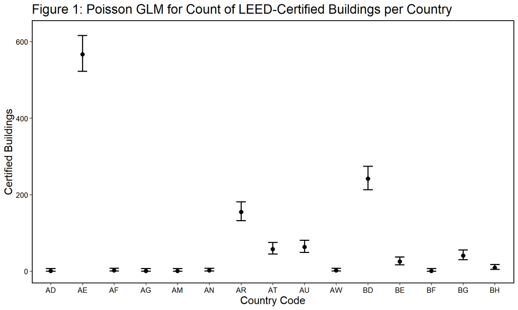

```r
plot_m1 = as_tibble(emmeans(m1, ~Country, type = "response")) |> head(15)

glmplot <-
  ggplot(data = plot_m1,
         aes(x=Country, y=rate, ymin = asymp.LCL, ymax = asymp.UCL))+
  geom_point(size=2.5)+
  geom_errorbar(width=0.3, linewidth=.8)+
  ylab("Certified Buildings")+
  xlab("Country Code")+
  ylim(0,625)+
  ggtitle("Figure 1: Poisson GLM for Count of LEED-Certified Buildings per Country")+
  practical_theme()+
  theme(text=element_text(size=15)) #Font size https://www.statology.org/ggplot-font-size/

glmplot #Show the plot
```

### Question 1b

Again, we plot the Poisson GLM (including the offset for GDP) for the first 15 countries. Some countries, like `AN`, are omitted from Figure 2 (and from our analysis for Question 1b) because we have no GDP data for them. The y-axis limits are the same as in Figure 1.

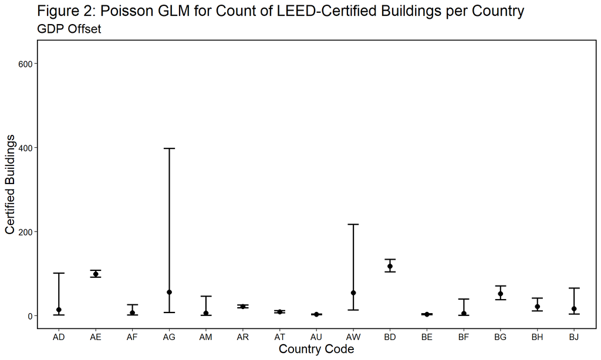

```r
plot_m1_offset = as_tibble(emmeans(m1_offset, ~Country, type = "response")) |> head(15)

glmplot_offset <-
  ggplot(data = plot_m1_offset,
         aes(x=Country, y=rate, ymin = asymp.LCL, ymax = asymp.UCL))+
  geom_point(size=2.5)+
  geom_errorbar(width=0.3, linewidth=.8)+
  ylab("Certified Buildings")+
  xlab("Country Code")+
  ggtitle("Figure 2: Poisson GLM for Count of LEED-Certified Buildings per Country",
          subtitle = "GDP Offset")+
  ylim(0,625)+ #Same scale as Figure 1
  practical_theme()+
  theme(text=element_text(size=15)) #Font size https://www.statology.org/ggplot-font-size/

glmplot_offset #Show the plot
```

### Question 2

Plotted here is the Poisson GLM for the number of Platinum-certified buildings constructed per year from 2000-2023. The vertical line before 2010 represents the cutoff used in the second Poisson GLM to approximate the rate of increase in Platinum-certified building construction.

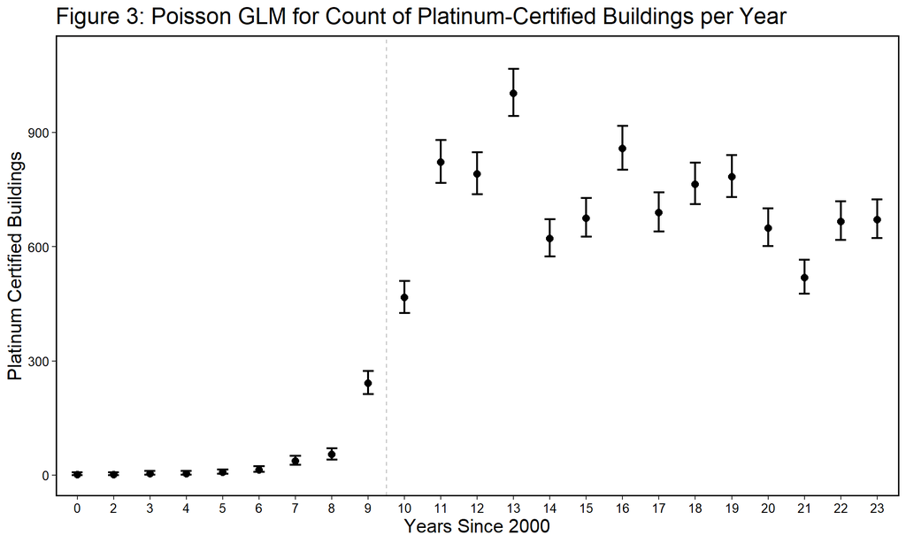

```r
plot_m2 = as_tibble(emmeans(m2, ~Year, type = "response"))

glmplot_year <-
  ggplot(data = plot_m2,
         aes(x=Year, y=rate, ymin = asymp.LCL, ymax = asymp.UCL))+
  geom_point(size=2.5)+
  geom_errorbar(width=0.3, linewidth=.8)+
  geom_vline(xintercept = 9.5, linewidth=.5, color="gray",linetype="dashed")+ #Cutoff year used
  ylab("Platinum Certified Buildings")+
  xlab("Years Since 2000")+
  ylim(0,1100)+ #Manualy set y axis limits
  ggtitle("Figure 3: Poisson GLM for Count of Platinum-Certified Buildings per Year")+
  practical_theme()+
  scale_x_discrete(labels= as.character(c(0,2:23)))+ #X labels
  theme(text=element_text(size=15)) #Font size https://www.statology.org/ggplot-font-size/
glmplot_year #Show the plot
```

**Note**

THANK YOU for a wonderful quarter! I have enjoyed this class immensely and am grateful to have developed a repertoire of tools for practical stats!